# Comparing NC WA, and CA data

0. load packages and data
1. larval dev rate vs temp
2. pupal mass vs temp
3. surv to pupation vs temp
4. north carolina blocked larval dev rate comparison
5. Statistical analyses
6. Kaplan meier curves

# 0. Load packages and data

```r
library(dplyr)
library(ggplot2)
library(Rmisc)
library(survminer)
library(survival)
library(lmerTest)

library(tidyr)
library(tidyverse)
library(plyr)
library(ggrepel)
library(janitor)
library(AICcmodavg)
library(ggsurvfit)
```

```r
comb <- read.csv("~/Desktop/GitHub/Pieris/PopulationCombData.csv", header = TRUE)
NewComb <- read.csv("~/Desktop/GitHub/Pieris/NEWCombData.csv", header = TRUE)
NC2 <- read.csv("~/Desktop/GitHub/Pieris/NCLarval2023.csv", header= T)
NC1 <- read.csv("~/Desktop/GitHub/Pieris/North_Carolina/NC_Larval_and_Realistic_Temps/Data/CleanedRound1.csv")
```

# 1. larval dev rate vs. temp

- Include LPIs

```r
comb$Dev.rate <- 1/comb$Age.pupa
NewComb$Dev.rate <- 1/NewComb$Age.pupa
```

```r
devratemeans <- summarySE(data = NewComb[NewComb$Surv.pupa == "Y", ],
                               measurevar = "Dev.rate",
                               groupvars = c("Treatment", "Population"))

devratemeans
```

| Treatment | Population | N | Dev.rate | sd | se | ci |
| --- | --- | --- | --- | --- | --- | --- |
| 16 | CA | 69 | 0.02975887 | 0.003619201 | 0.0004357006 | 0.0008694269 |
| 16 | NC | 85 | 0.02771393 | 0.002707112 | 0.0002936275 | 0.0005839105 |
| 16 | WA | 39 | 0.03039735 | 0.003698106 | 0.0005921709 | 0.0011987873 |
| 21 | CA | 84 | 0.04718997 | 0.005243523 | 0.0005721153 | 0.0011379143 |
| 21 | NC | 95 | 0.04418025 | 0.004769577 | 0.0004893482 | 0.0009716124 |
| 21 | WA | 33 | 0.05079506 | 0.005785304 | 0.0010070922 | 0.0020513797 |
| 26 | CA | 49 | 0.07168389 | 0.010081633 | 0.0014402333 | 0.0028957831 |
| 26 | NC | 54 | 0.08033669 | 0.008834384 | 0.0012022074 | 0.0024113227 |
| 26 | WA | 35 | 0.07283573 | 0.006868893 | 0.0011610547 | 0.0023595471 |
| 30 | CA | 87 | 0.08600860 | 0.012015648 | 0.0012882127 | 0.0025608821 |

[output cut: 5 more lines]

```r
devratemeans$Treatment <- as.factor(devratemeans$Treatment)
```

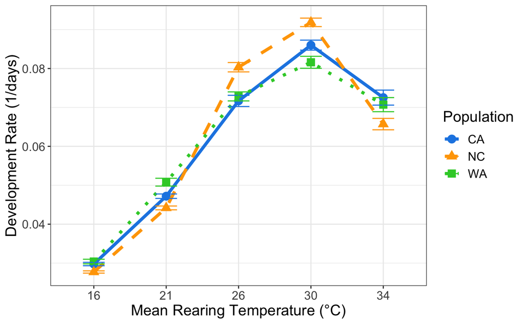

```r
NCWACAdevrate <- ggplot(data = devratemeans, aes(x = Treatment, y = Dev.rate, group = Population, linetype = Population, shape = Population, color = Population)) +
  theme_bw() +
  geom_point(size = 3.5) +
  geom_line(size = 1.5) +
  font("xy", size = 15)+
  font("x.text", size = 12)+
  font("y.text", size = 12)+
  font("legend.title", size = 15)+
  font("legend.text", size = 12)+
  labs(x = "Mean Rearing Temperature (°C)", y = "Development Rate (1/days)", group = "Population", linetype = "Population",
       shape = "Population") +
  scale_linetype_manual(values = c("solid", "dashed", "dotted")) +
  scale_shape_manual(values = c(19, 17, 15)) +
  geom_errorbar(aes(ymin = Dev.rate - se, ymax = Dev.rate + se), width = 0.3, linetype = "solid") +
  scale_color_manual(values = c("#1E88E5", "orange", "lime green"))

NCWACAdevrate
```

```r
NA
```

```r
ggsave("~/Desktop/GitHub/Pieris/Thesis/LarvalDevRate.png", NCWACAdevrate, width = 8, height = 5)
```

# 2. Pupal mass vs. temp

- Exclude LPIs

```r
massmeans <- summarySE(data = NewComb[NewComb$Surv.pupa == "Y" & NewComb$PupateOK == "Y" & !is.na(NewComb$Mass.pupa), ],
                               measurevar = "Mass.pupa",
                               groupvars = c("Treatment", "Population"))

massmeans
```

| Treatment | Population | N | Mass.pupa | sd | se | ci |
| --- | --- | --- | --- | --- | --- | --- |
| 16 | CA | 35 | 188.5751 | 25.77773 | 4.357231 | 8.854959 |
| 16 | NC | 16 | 189.5962 | 35.57897 | 8.894741 | 18.958693 |
| 16 | WA | 20 | 179.6820 | 22.30123 | 4.986707 | 10.437297 |
| 21 | CA | 59 | 188.4520 | 23.82862 | 3.102222 | 6.209772 |
| 21 | NC | 28 | 188.5021 | 32.00525 | 6.048424 | 12.410342 |
| 21 | WA | 23 | 176.3100 | 23.78171 | 4.958829 | 10.283983 |
| 26 | CA | 37 | 169.8927 | 23.59752 | 3.879409 | 7.867806 |
| 26 | NC | 33 | 205.2624 | 33.37387 | 5.809645 | 11.833859 |
| 26 | WA | 32 | 160.1125 | 26.54477 | 4.692496 | 9.570409 |
| 30 | CA | 78 | 160.6655 | 16.59695 | 1.879235 | 3.742035 |

[output cut: 5 more lines]

```r
#massmeans$Treatment <- as.factor(massmeans$Treatment)
```

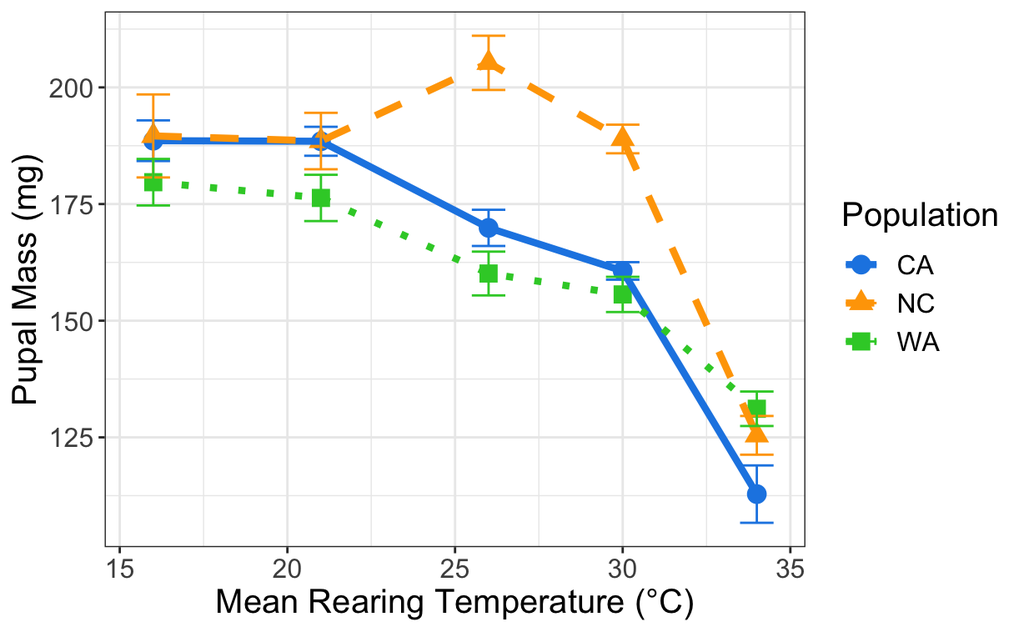

```r
NCWACAmass <- ggplot(data = massmeans, aes(x = Treatment, y = Mass.pupa, group = Population, linetype = Population, shape = Population, color = Population)) +
  theme_bw() +
  geom_point(size = 3.5) +
  geom_line(size = 1.5) +
  labs(x = "Mean Rearing Temperature (°C)", y = "Pupal Mass (mg)", group = "Population", linetype = "Population",
       shape = "Population") +
  font("xy", size = 15)+
  font("x.text", size = 12)+
  font("y.text", size = 12)+
  font("legend.title", size = 15)+
  font("legend.text", size = 12)+
  scale_linetype_manual(values = c("solid", "dashed", "dotted")) +
  scale_shape_manual(values = c(19, 17, 15)) +
  geom_errorbar(aes(ymin = Mass.pupa - se, ymax = Mass.pupa + se), width = 1, linetype = "solid") +
  scale_color_manual(values= c("#1E88E5", "orange", "lime green"))

NCWACAmass
```

```r
NA
```

```r
ggsave("~/Desktop/GitHub/Pieris/Thesis/LarvalMass.png", NCWACAmass, width = 8, height = 5)
```

# 3. Surv to pupation vs. temp

- Include LPIs

#3A. This is all trash… done before 2nd NC experiment

```r
survpercsum <- summarySE(data = comb,
                         measurevar = "CID",
                         groupvars = c("Treatment", "Expt", "Surv.pupa"))

survpercsum
```

| Treatment | Expt | Surv.pupa | N | CID | sd | se | ci |
| --- | --- | --- | --- | --- | --- | --- | --- |
| 16 | CA | N | 12 | 309.91667 | 51.34457 | 14.821901 | 32.622785 |
| 16 | CA | Y | 69 | 304.81159 | 63.98214 | 7.702544 | 15.370188 |
| 16 | NC1 | N | 36 | 277.08333 | 110.30591 | 18.384318 | 37.322149 |
| 16 | NC1 | Y | 29 | 360.24138 | 14.10586 | 2.619393 | 5.365583 |
| 16 | NC2 | N | 4 | 134.50000 | 11.09054 | 5.545268 | 17.647518 |
| 16 | NC2 | Y | 56 | 87.25000 | 42.50016 | 5.679323 | 11.381617 |
| 16 | WA1 | N | 8 | 59.62500 | 30.90510 | 10.926602 | 25.837307 |
| 16 | WA1 | Y | 14 | 49.92857 | 34.03497 | 9.096228 | 19.651206 |
| 16 | WA2 | N | 4 | 1082.25000 | 40.28544 | 20.142720 | 64.103125 |
| 16 | WA2 | Y | 24 | 1066.20833 | 41.66322 | 8.504470 | 17.592837 |

[output cut: 36 more lines]

```r
survdata <- data.frame(Treatment = rep(c(16, 21, 26, 30, 34), times = 4),
                       surv.perc = 0,
                       Expt = rep(c("NC", "WA1", "WA2", "CA"), each = 5))

survdata$Treatment <- as.factor(survdata$Treatment)
```

```r
survdata[1, 2] <- survpercsum[4, 4] / (survpercsum[4, 4] + survpercsum[3, 4])
survdata[2, 2] <- survpercsum[12, 4] / (survpercsum[12, 4] + survpercsum[11, 4])
survdata[3, 2] <- survpercsum[20, 4] / (survpercsum[20, 4] + survpercsum[19, 4])
survdata[4, 2] <- survpercsum[28, 4] / (survpercsum[28, 4] + survpercsum[27, 4])
survdata[5, 2] <- survpercsum[36, 4] / (survpercsum[36, 4] + survpercsum[35, 4])



survdata[6, 2] <- survpercsum[6, 4] / (survpercsum[6, 4] + survpercsum[5, 4])
survdata[7, 2] <- survpercsum[14, 4] / (survpercsum[14, 4] + survpercsum[13, 4])
survdata[8, 2] <- survpercsum[22, 4] / (survpercsum[22, 4] + survpercsum[21, 4])
survdata[9, 2] <- survpercsum[30, 4] / (survpercsum[30, 4] + survpercsum[29, 4])
survdata[10, 2] <- survpercsum[38, 4] / (survpercsum[38, 4] + survpercsum[37, 4])


survdata[11, 2] <- survpercsum[8, 4] / (survpercsum[8, 4] + survpercsum[7, 4])
survdata[12, 2] <- survpercsum[16, 4] / (survpercsum[16, 4] + survpercsum[15, 4])
survdata[13, 2] <- survpercsum[24, 4] / (survpercsum[24, 4] + survpercsum[23, 4])
survdata[14, 2] <- survpercsum[32, 4] / (survpercsum[32, 4] + survpercsum[31, 4])
survdata[15, 2] <- survpercsum[40, 4] / (survpercsum[40, 4] + survpercsum[39, 4])

survdata[16, 2] <- survpercsum[2, 4] / (survpercsum[2, 4] + survpercsum[1, 4])
survdata[17, 2] <- survpercsum[10, 4] / (survpercsum[10, 4] + survpercsum[9, 4])
survdata[18, 2] <- survpercsum[18, 4] / (survpercsum[18, 4] + survpercsum[17, 4])
survdata[19, 2] <- survpercsum[26, 4] / (survpercsum[26, 4] + survpercsum[25, 4])
survdata[20, 2] <- survpercsum[34, 4] / (survpercsum[34, 4] + survpercsum[33, 4])
```

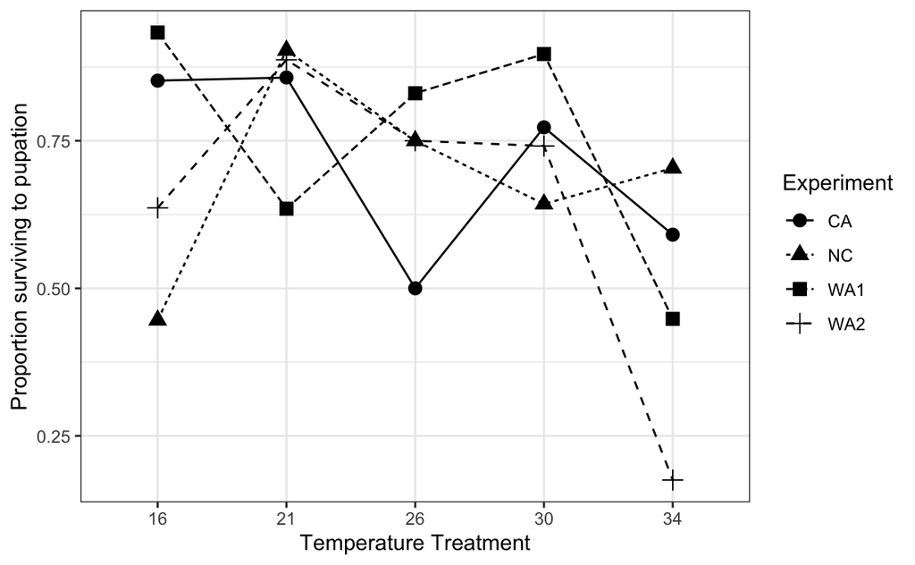

```r
NCWACAsurv <- ggplot(data = survdata, aes(x = Treatment, y = surv.perc, group = Expt, linetype = Expt,
                                       shape = Expt)) +
  theme_bw() +
  geom_point(size = 3) +
  geom_line() +
  labs(x = "Temperature Treatment", y = "Proportion surviving to pupation", group = "Experiment", linetype = "Experiment",
       shape = "Experiment")
  #scale_linetype_manual(values = c("solid", "dashed", "dotted", "longdashed")) +
  #scale_shape_manual(values = c(19, 2, 5, 1))

NCWACAsurv
```

```r
NA
```

```r
ggsave("~/Desktop/GitHub/Pieris/NCWACAsurv.png", NCWACAsurv, width = 8, height = 5)
```

## 3B. Surv to Pupation vs Temp (With intermediates being survivors)

- Include LPIs

[output not shown]

[output cut: 20 more lines]

```r
survdata <- data.frame(Treatment = rep(c(16, 21, 26, 30, 34), times = 3),
                       surv.perc = 0,
                       N = 0,
                       Population = rep(c("NC", "WA", "CA"), each = 5),
                       se = 0)
```

```r
survdata[1, 2] <- survpercsum[4, 4] / (survpercsum[4, 4] + survpercsum[3, 4])
survdata[2, 2] <- survpercsum[10, 4] / (survpercsum[10, 4] + survpercsum[9, 4])
survdata[3, 2] <- survpercsum[16, 4] / (survpercsum[16, 4] + survpercsum[15, 4])
survdata[4, 2] <- survpercsum[22, 4] / (survpercsum[22, 4] + survpercsum[21, 4])
survdata[5, 2] <- survpercsum[28, 4] / (survpercsum[28, 4] + survpercsum[27, 4])

survdata[6, 2] <- survpercsum[6, 4] / (survpercsum[6, 4] + survpercsum[5, 4])
survdata[7, 2] <- survpercsum[12, 4] / (survpercsum[12, 4] + survpercsum[11, 4])
survdata[8, 2] <- survpercsum[18, 4] / (survpercsum[18, 4] + survpercsum[17, 4])
survdata[9, 2] <- survpercsum[24, 4] / (survpercsum[24, 4] + survpercsum[23, 4])
survdata[10, 2] <- survpercsum[30, 4] / (survpercsum[30, 4] + survpercsum[29, 4])

survdata[11, 2] <- survpercsum[2, 4] / (survpercsum[2, 4] + survpercsum[1, 4])
survdata[12, 2] <- survpercsum[8, 4] / (survpercsum[8, 4] + survpercsum[7, 4])
survdata[13, 2] <- survpercsum[14, 4] / (survpercsum[14, 4] + survpercsum[13, 4])
survdata[14, 2] <- survpercsum[20, 4] / (survpercsum[20, 4] + survpercsum[19, 4])
survdata[15, 2] <- survpercsum[26, 4] / (survpercsum[26, 4] + survpercsum[25, 4])

survdata[1,3] <- (survpercsum[4, 4] + survpercsum[3, 4])
survdata[2,3] <-(survpercsum[10, 4] + survpercsum[9, 4])
survdata[3,3]<-(survpercsum[16, 4] + survpercsum[15, 4])
survdata[4,3]<-(survpercsum[22, 4] + survpercsum[21, 4])
survdata[5,3]<-(survpercsum[28, 4] + survpercsum[27, 4])
survdata[6,3]<-(survpercsum[6, 4] + survpercsum[5, 4])
survdata[7,3]<-(survpercsum[12, 4] + survpercsum[11, 4])
survdata[8,3]<-(survpercsum[18, 4] + survpercsum[17, 4])
survdata[9,3]<-(survpercsum[24, 4] + survpercsum[23, 4])
survdata[10,3]<- (survpercsum[30, 4] + survpercsum[29, 4])
survdata[11,3]<-(survpercsum[2, 4] + survpercsum[1, 4])
survdata[12,3]<-(survpercsum[8, 4] + survpercsum[7, 4])
survdata[13,3]<-(survpercsum[14, 4] + survpercsum[13, 4])
survdata[14,3]<- (survpercsum[20, 4] + survpercsum[19, 4])
survdata[15,3]<-(survpercsum[26, 4] + survpercsum[25, 4])
```

```r
for (i in 1:length(survdata$se)){
  survdata[i,5] = sqrt((survdata[i,2]*(1-survdata[i,2]))/survdata[i,3])
}
```

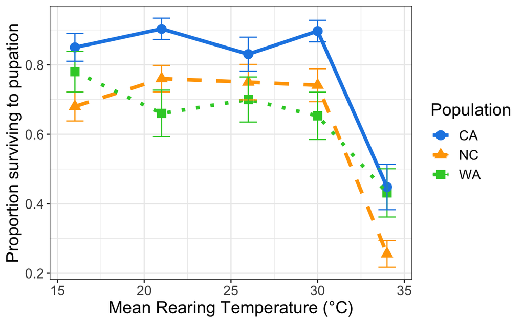

```r
NCWACAsurv <- ggplot(data = survdata, aes(x = Treatment, y = surv.perc, group = Population, linetype = Population, shape = Population, color = Population)) +
  theme_bw() +
  geom_point(size = 3.5) +
  geom_line(size = 1.5) +
  font("xy", size = 15)+
  font("x.text", size = 12)+
  font("y.text", size = 12)+
  font("legend.title", size= 15)+
  font("legend.text", size = 12)+
  labs(x = "Mean Rearing Temperature (°C)", y = "Proportion surviving to pupation", group = "Population", linetype = "Population", shape = "Population") +
  scale_linetype_manual(values = c("solid", "dashed", "dotted")) +
  scale_shape_manual(values = c(19, 17, 15)) +
  scale_color_manual(values = c("#1E88E5", "orange", "lime green"))+
  geom_errorbar(aes(ymin = surv.perc - se, ymax = surv.perc +se), width = 1, linetype = "solid")

NCWACAsurv
```

```r
ggsave("~/Desktop/GitHub/Pieris/Thesis/LarvalSurvival.png", NCWACAsurv, width = 8, height = 5)
```

##3C. Survival Proportions (With intermediates being deaths)

```r
survpercsum <- summarySE(data = NewComb1,
                         measurevar = "CID",
                         groupvars = c("Treatment", "Population", "Surv.pupa"))

survpercsum
```

| Treatment | Population | Surv.pupa | N | CID | sd | se | ci |
| --- | --- | --- | --- | --- | --- | --- | --- |
| 16 | CA | N | 46 | 305.32609 | 62.74430 | 9.251142 | 18.63276 |
| 16 | CA | Y | 34 | 307.55882 | 62.07092 | 10.645075 | 21.65757 |
| 16 | NC | N | 108 | 224.63889 | 131.43219 | 12.647068 | 25.07134 |
| 16 | NC | Y | 17 | 93.23529 | 83.31081 | 20.205840 | 42.83447 |
| 16 | WA | N | 29 | 411.82759 | 503.20956 | 93.443670 | 191.41068 |
| 16 | WA | Y | 21 | 911.95238 | 362.26585 | 79.052890 | 164.90144 |
| 21 | CA | N | 34 | 217.94118 | 94.73342 | 16.246647 | 33.05405 |
| 21 | CA | Y | 59 | 240.18644 | 89.94950 | 11.710428 | 23.44097 |
| 21 | NC | N | 97 | 187.61856 | 125.48833 | 12.741410 | 25.29150 |
| 21 | NC | Y | 28 | 80.42857 | 77.51579 | 14.649108 | 30.05749 |

[output cut: 20 more lines]

```r
survdata1 <- data.frame(Treatment = rep(c(16, 21, 26, 30, 34), times = 3),
                       surv.perc = 0,
                       N = 0,
                       Population = rep(c("NC", "WA", "CA"), each = 5),
                       se = 0)
```

```r
survdata1[1, 2] <- survpercsum[4, 4] / (survpercsum[4, 4] + survpercsum[3, 4])
survdata1[2, 2] <- survpercsum[10, 4] / (survpercsum[10, 4] + survpercsum[9, 4])
survdata1[3, 2] <- survpercsum[16, 4] / (survpercsum[16, 4] + survpercsum[15, 4])
survdata1[4, 2] <- survpercsum[22, 4] / (survpercsum[22, 4] + survpercsum[21, 4])
survdata1[5, 2] <- survpercsum[28, 4] / (survpercsum[28, 4] + survpercsum[27, 4])

survdata1[6, 2] <- survpercsum[6, 4] / (survpercsum[6, 4] + survpercsum[5, 4])
survdata1[7, 2] <- survpercsum[12, 4] / (survpercsum[12, 4] + survpercsum[11, 4])
survdata1[8, 2] <- survpercsum[18, 4] / (survpercsum[18, 4] + survpercsum[17, 4])
survdata1[9, 2] <- survpercsum[24, 4] / (survpercsum[24, 4] + survpercsum[23, 4])
survdata1[10, 2] <- survpercsum[30, 4] / (survpercsum[30, 4] + survpercsum[29, 4])

survdata1[11, 2] <- survpercsum[2, 4] / (survpercsum[2, 4] + survpercsum[1, 4])
survdata1[12, 2] <- survpercsum[8, 4] / (survpercsum[8, 4] + survpercsum[7, 4])
survdata1[13, 2] <- survpercsum[14, 4] / (survpercsum[14, 4] + survpercsum[13, 4])
survdata1[14, 2] <- survpercsum[20, 4] / (survpercsum[20, 4] + survpercsum[19, 4])
survdata1[15, 2] <- survpercsum[26, 4] / (survpercsum[26, 4] + survpercsum[25, 4])

survdata1[1,3] <- (survpercsum[4, 4] + survpercsum[3, 4])
survdata1[2,3] <-(survpercsum[10, 4] + survpercsum[9, 4])
survdata1[3,3]<-(survpercsum[16, 4] + survpercsum[15, 4])
survdata1[4,3]<-(survpercsum[22, 4] + survpercsum[21, 4])
survdata1[5,3]<-(survpercsum[28, 4] + survpercsum[27, 4])
survdata1[6,3]<-(survpercsum[6, 4] + survpercsum[5, 4])
survdata1[7,3]<-(survpercsum[12, 4] + survpercsum[11, 4])
survdata1[8,3]<-(survpercsum[18, 4] + survpercsum[17, 4])
survdata1[9,3]<-(survpercsum[24, 4] + survpercsum[23, 4])
survdata1[10,3]<- (survpercsum[30, 4] + survpercsum[29, 4])
survdata1[11,3]<-(survpercsum[2, 4] + survpercsum[1, 4])
survdata1[12,3]<-(survpercsum[8, 4] + survpercsum[7, 4])
survdata1[13,3]<-(survpercsum[14, 4] + survpercsum[13, 4])
survdata1[14,3]<- (survpercsum[20, 4] + survpercsum[19, 4])
survdata1[15,3]<-(survpercsum[26, 4] + survpercsum[25, 4])
```

```r
for (i in 1:length(survdata1$se)){
  survdata1[i,5] = sqrt((survdata1[i,2]*(1-survdata1[i,2]))/survdata1[i,3])
}
```

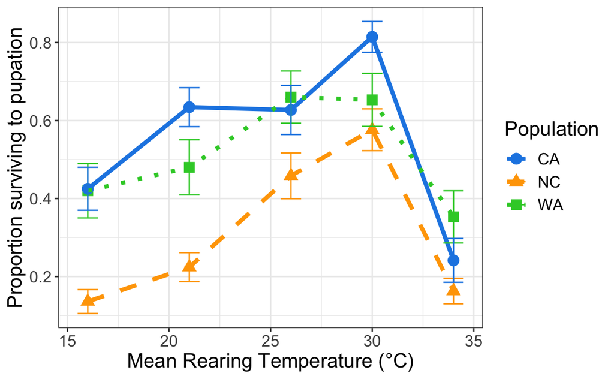

```r
NCWACAsurv <- ggplot(data = survdata1, aes(x = Treatment, y = surv.perc, group = Population, linetype = Population, shape = Population, color = Population)) +
  theme_bw() +
  geom_point(size = 3.5) +
  geom_line(size = 1.5) +
  font("xy", size = 15)+
  font("x.text", size = 12)+
  font("y.text", size = 12)+
  font("legend.title", size= 15)+
  font("legend.text", size = 12)+
  labs(x = "Mean Rearing Temperature (°C)", y = "Proportion surviving to pupation", group = "Population", linetype = "Population", shape = "Population") +
  scale_linetype_manual(values = c("solid", "dashed", "dotted")) +
  scale_shape_manual(values = c(19, 17, 15)) +
  scale_color_manual(values = c("#1E88E5", "orange", "lime green"))+
  geom_errorbar(aes(ymin = surv.perc - se, ymax = surv.perc +se), width = 1, linetype = "solid")

NCWACAsurv
```

```r
ggsave("~/Desktop/GitHub/Pieris/Thesis/LarvalSurvival.png", NCWACAsurv, width = 8, height = 5)
```

##3D. Time of death versus rearing temperature

```r
TODmeans <- summarySE(data = NewComb[!is.na(NewComb$Age.death), ],
                               measurevar = "Age.death",
                               groupvars = c("Treatment", "Population"))

TODmeans

#TODmeans$Treatment <- as.factor(TODmeans$Treatment)
#survdata1 <- survdata %>% select(Treatment, Population, surv.perc)

#TODmeans <- merge(TODmeans, survdata1, by = c("Treatment", "Population"))
#TODmeans$mort.perc <- 1- TODmeans$surv.perc
#TODmeans$Size <- TODmeans$surv.perc*5
```

```r
CombTOD <- ggplot(data = TODmeans, aes(x = Treatment, y = Age.death, group = Population, linetype = Population, shape = Population, color = Population)) +
  theme_bw() +
  geom_point(size=3.5) +
  geom_line(size = 1.5) +
  labs(x = "Mean temperature", y = "Average time to death (Days)", group = "Population", linetype = "Population",
       shape = "Population")+
  font("xy", size = 15)+
  font("x.text", size = 12)+
  font("y.text", size = 12)+
  font("legend.title", size= 15)+
  font("legend.text", size = 12)+
  scale_linetype_manual(values = c("solid", "dashed", "dotted")) +
  scale_shape_manual(values = c(19, 17, 15))+
  scale_color_manual(values = c("#1E88E5", "orange", "lime green"))+
  geom_errorbar(aes(ymin = Age.death - se, ymax = Age.death + se), width = 1, linetype = "solid")

CombTOD
```

```r
ggsave("~/Desktop/GitHub/Pieris/NCWACAtimedeath.png", CombTOD, width = 8, height = 5)
```

# Growth rate graphs

### Mean mass and SE

```r
pupalmean <- summarySE(data = NewComb[NewComb$Surv.pupa == "Y", ], measurevar = "Mass.pupa", groupvars = c("Treatment", "Population"))

pupalmean

pupalmean$Mass.se <- pupalmean$se

pupalmean <- pupalmean %>%
  select(Treatment, Population, N, Mass.pupa, Mass.se)
```

### Mean dev time and SE

```r
pupaltimemean <- summarySE(data = NewComb[NewComb$Surv.pupa == "Y", ], measurevar = "Age.pupa", groupvars = c("Treatment", "Population"))

pupaltimemean

pupaltimemean$Time.se <- pupaltimemean$se

pupaltimemean <- pupaltimemean %>%
  select(Treatment, Population, N, Age.pupa, Time.se)
```

### Merge together

```r
pupalmeans <- merge(pupalmean, pupaltimemean, by = c("Treatment", "Population", "N"))
```

## Add in dvelopment rate

```r
NewComb$Dev.rate <- 1 / (NewComb$Age.pupa)
```

```r
pupalratemean <- summarySE(data = NewComb[NewComb$Surv.pupa == "Y", ], measurevar = "Dev.rate", groupvars = c("Treatment", "Population"))

pupalratemean

pupalratemean$Rate.se <- pupalratemean$se

pupalratemean <- pupalratemean %>%
  select(Treatment, Population, N, Dev.rate, Rate.se)
```

```r
pupalmeans <- merge(pupalmeans, pupalratemean, by = c("Treatment", "Population", "N"))

pupalmeans$Treatment <- as.factor(pupalmeans$Treatment)
```

```r
pupalgraph <- ggplot(data = pupalmeans, aes(x = Age.pupa, y = Mass.pupa, color = Population, shape = Treatment)) +
  theme_bw() +
  geom_point(size = 3) +
  geom_errorbar(aes(ymin = Mass.pupa - Mass.se, ymax = Mass.pupa + Mass.se)) +
  geom_errorbarh(aes(xmin = Age.pupa - Time.se, xmax = Age.pupa + Time.se)) +
  guides(scale = "none") +
  scale_color_manual(values = c("#1E88E5", "lime green", "orange")) +
  labs(x = "Time until pupation (days)", y = "Mass at pupation (mg)", color = "Mean temperature treatment", shape = "Treatment")


pupalgraph
```

#4.North Carolina Experiment Comparisons

```r
NCComb <- comb[comb$Population == "NC", ]
```

```r
write.csv(NCComb, file = "~/Desktop/GitHub/Pieris/NCLarvalCombData.csv")
```

```r
NCdevratemeans <- summarySE(data = NCComb[NCComb$Surv.pupa == "Y", ],
                               measurevar = "Dev.rate",
                               groupvars = c("Treatment"))

NCdevratemeans

NCdevratemeans$Treatment <- as.factor(NCdevratemeans$Treatment)
```

```r
NCdevrate <- ggplot(data = NCdevratemeans, aes(x = Treatment, y = Dev.rate)) +
  theme_bw() +
  geom_point(size = 3) +
  geom_line(group= 1) +
  labs(x = "Mean Rearing Temperature", y = "Development Rate")

NCdevrate
```

```r
ggsave("~/Desktop/GitHub/Pieris/NCDevRateComb.png", NCdevrate, width = 8, height = 5)
```

#5. Statistical Analyses

```r
#To prevent the issues from switching between factor and numeric, from now on, Treatment is a factor and temperature is the same thing but numeric
NewComb$Temperature <- NewComb$Treatment
NewComb$Treatment <- as.factor(NewComb$Treatment)
```

```r
popcomb1 <- glm(Age.pupa ~ Treatment*Population, data = NewComb)

summary(popcomb1)
anova(popcomb1, test= "Chisq")
```

```r
popcomb2 <- glm(Age.pupa ~ poly(Temperature, degree = 2)*Population, data = NewComb)

summary(popcomb2)
anova(popcomb2, test = "Chisq")
```

```r
anova(popcomb1, popcomb2, test = "Chisq")
```

```r
popcomb3 <- glm(Age.pupa ~ Treatment*Population, data = NewComb[NewComb$PupateOK == "Y", ])

summary(popcomb)
anova(popcomb, test= "Chisq")
```

```r
popcomb4 <- glm(Age.pupa ~ poly(Temperature, degree = 2)*Population, data = NewComb[NewComb$PupateOK == "Y", ])

summary(popcomb4)
anova(popcomb4, test = "Chisq")
```

```r
anova(popcomb3, popcomb4, test = "Chisq")
```

```r
NewComb$Expt = as.factor(NewComb$Expt)
ncblock <- glm(Age.pupa ~ poly(Temperature, 2)*Expt, data = NewComb[NewComb$Population == "NC", ])

summary(ncblock)
anova(ncblock, test="Chisq")
```

```r
ncblock2 <- lmer(Age.pupa ~ poly(Temperature) + (Temperature | Expt) , data = NewComb[NewComb$Population == "NC", ])

summary(ncblock2)
anova(ncblock2, test="Chisq")
```

```r
nc2sib <- lmer(Time.pupa ~ poly(Mean.temp,2)+(1 | Sib), data = NC2[is.na(NC2$Time.pupa) == FALSE, ])

summary(nc2sib)
anova(nc2sib, test="Chisq")
```

```r
NC1$SIB <- as.factor(NC1$SIB)
nc1sib <- lmer(Time.pupa ~ poly(Mean.Temp ,2)* (Mean.Temp | SIB), data = NC1[is.na(NC1$Time.pupa) == FALSE, ])

summary(nc1sib)
anova(nc1sib, test="Chisq")
```

```r
nc2hatchloc <- glm(Time.pupa ~ poly(Mean.temp, 2)*Hatch.loc, data = NC2[is.na(NC2$Time.pupa) == FALSE, ])

summary(nc2hatchloc)
anova(nc2hatchloc, test = "Chisq")
```

```r
NewComb$binarypupalsurv <- 0
NewComb <- NewComb %>%
  mutate(binarypupalsurv = case_when(Surv.pupa == "Y" ~ 1,
                              Surv.pupa == "N" ~ 0))
```

```r
larvalsurv <- glm(binarypupalsurv ~ Population*Temperature, data = NewComb, family = binomial(link= "logit"))

summary(larvalsurv)
anova(larvalsurv, test = "Chisq")
```

Interaction not significant so do additive instead…

```r
larvalsurv <- glm(binarypupalsurv ~ Population+Temperature, data = NewComb, family = binomial(link= "logit"))

summary(larvalsurv)
anova(larvalsurv, test = "Chisq")
```

```r
larvalsurv1 <- glm(Age.death ~ Population*poly(Treatment, 2)*binarypupalsurv, data = NewComb)

summary(larvalsurv1)
anova(larvalsurv1, test = "Chisq")
```

```r
larvalsurv2 <- glm(Age.death ~ Population*Treatment, data = NewComb)

summary(larvalsurv2)
anova(larvalsurv2, test = "Chisq")
```

```r
anova(larvalsurv1, larvalsurv2, test = "Chisq")
```

```r
NCSurvBlock <- glm(binarypupalsurv ~ Treatment*Expt, data = NewComb[NewComb$Population == "NC", ], family = binomial(link= "logit"))

summary(NCSurvBlock)
anova(NCSurvBlock, test = "Chisq")
```

```r
glm(Mass.pupa ~ Temperature*Population, data = NewComb)

summary(glm(Mass.pupa ~ Temperature*Population, data = NewComb))
anova(glm(Mass.pupa ~ Temperature*Population, data = NewComb), test = "Chisq")
```

```r
anova(glm(Age.pupa ~ poly(Temperature, 2)*Population*PupateOK, data= NewComb), test = "Chisq")
```

#6. Kaplan Meier- SCRAPPED

## 6a. North Carolina Larval Kaplan Meier Curve Creation

Creating an Age.exit column that is either the day the individual died or the day it pupated

```r
NCSurv <- NewComb[NewComb$Population == "NC", ]
NCSurv$Treatment <- as.factor(NCSurv$Treatment)
NCSurv <- NCSurv %>%
  mutate(Age.exit = case_when(!is.na(Age.death) ~ Age.death,
                              !is.na(Age.pupa) ~ Age.pupa))
```

Creating a censoring column where we are censoring the individuals that pupated

```r
NCSurv$censor <- 0

for(i in 1:length(NCSurv$Surv.pupa)){
  if((NCSurv[i, 11]) == "Y"){
    NCSurv[i, 23] <- 1
  } else if((NCSurv[i, 11]) == "N"){
    NCSurv[i, 23] <- 0
  }
}
```

Creating the Survival object for use with kaplan meier

```r
NCsurvobject <- Surv(NCSurv$Age.exit, NCSurv$censor)
```

```r
View(NCsurvobject)
```

Creating the kaplan meier model

```r
NCsurvmodel <- survfit(NCsurvobject ~ Treatment, data = NCSurv )
```

```r
View(survmodel)
```

Plotting Kaplan meier curve for North Carolina Larva

```r
plot(NCsurvmodel)

NCsurvplot <- ggsurvplot(fit = NCsurvmodel,
           data = NCSurv,
           xlab = "Days in experiment",
           ylab = "Survival probability",
           palette = c("purple", "#1E88E5", "lime green", "orange", "#D81B60"),
           conf.int=T)

NCsurvplotlegend <- NCsurvplot$plot + theme(legend.position = "right")

NCsurvplotlegend
```

```r
ggsave("~/Desktop/GitHub/Pieris/NCLarvalKP.png", survplotlegend, width = 8, height = 5)
```

Getting weird looking graph for NC… Let’s try calculating the mean and stardard deviations of the age.pupal column for each treatment, so we can exlude individuals who are more than two standard devs from the mean

```r
NCSurvSum <- summarySE(data = NCSurv, measurevar = "Age.exit", groupvars = c("Treatment", "Surv.pupa"))

NCSurvSum <- NCSurvSum %>% select(Treatment, Surv.pupa, Age.exit, sd)

NCSurvSum$Age.limit <- NCSurvSum$Age.exit + NCSurvSum$sd*2

NCSurvSum
```

When I do this, it actually doesn’t exclude anyone so let me create a boxplot to look at the data

```r
survbox <- ggplot(data = NCSurv, aes(x = Treatment, y = Age.exit)) +
  theme_bw() +
  geom_boxplot() +
  labs(x = "Treatment", y = "Age to experimental exit")

survbox
```

Lets try using slice_max in dplyer to just remove the highest age.exit or two for each treatment group

```r
NCSurv1 <- NCSurv1 %>%
  group_by(Treatment) %>%
  filter(Age.exit < max(Age.exit))
```

Creating the Survival object for use with kaplan meier

```r
NCsurv1object <- Surv(NCSurv1$Age.exit, NCSurv1$censor)
```

```r
View(NCsurv1object)
```

Creating the kaplan meier model

```r
NCsurv1model <- survfit(NCsurv1object ~ Treatment, data = NCSurv1 )
```

```r
View(survmodel)
```

Plotting Kaplan meier curve for North Carolina Larva

```r
plot(NCsurv1model)

NCsurv1plot <- ggsurvplot(fit = NCsurv1model,
           data = NCSurv1,
           xlab = "Days in experiment",
           ylab = "Survival probability",
           palette = c("purple", "#1E88E5", "lime green", "orange", "#D81B60"),
           conf.int=T)

NCsurv1plotlegend <- NCsurv1plot$plot + theme(legend.position = "right")

NCsurv1plotlegend
```

This didnt do anything either… at this point I’m saying no more kaplan meier

## 6b. Kaplan Meier curve for California Larval

Creating an Age.exit column that is either the day the individual died or the day it pupated

```r
CASurv <- comb[comb$Population == "CA", ]
CASurv <- CASurv %>%
  mutate(Age.exit = case_when(!is.na(Age.death)~ Age.death,
                              !is.na(Age.pupa)~ Age.pupa))
```

Creating a censoring column where we are censoring the individuals that pupated

```r
CASurv$censor <- 0

for(i in 1:length(CASurv$Age.death)){
  if(is.na(CASurv[i, 4]) == TRUE){
    CASurv[i, 12] <- 1
  } else if(is.na(CASurv[i, 4]) == FALSE){
    CASurv[i, 12] <- 2
  }
}
```

Creating a surv object for use with kaplan meier

```r
CAsurvobject <- Surv(CASurv$Age.death, CASurv$censor)
```

Creating the kaplan meier model

```r
CAsurvmodel <- survfit(CAsurvobject ~ Treatment, data = CASurv )
```

Plotting the Kaplan Meier Curves for California larval experiment

```r
plot(CAsurvmodel)

CAsurvplot <- ggsurvplot(fit = CAsurvmodel,
           data = CASurv,
           xlab = "Days in experiment",
           ylab = "Survival probability",
           palette = c("purple", "#1E88E5", "lime green", "orange", "#D81B60"),
           conf.int=T)

CAsurvplotlegend <- CAsurvplot$plot + theme(legend.position = "right")

CAsurvplotlegend
```

```r
ggsave("~/Desktop/GitHub/Pieris/CALarvalKP.png", survplotlegend, width = 8, height = 5)
```

## 6c. Washington larval kaplan meier curve (NOT DONE YET)

```r
WASurv <- comb[comb$Population == "WA", ]

WASurv$died <- 0

for(i in 1:length(WASurv$Age.death)){
  if(is.na(WASurv[i, 4]) == TRUE){
    WASurv[i, 11] <- 0
  } else if(is.na(WASurv[i, 4]) == FALSE){
    WASurv[i, 11] <- 1
  }
}
```

```r
survobject <- Surv(WASurv$Age.death, WASurv$died)
```

```r
survmodel <- survfit(survobject ~ Treatment, data = WASurv )
```

```r
survplot <- ggsurvplot(fit = survmodel,
           data = WASurv,
           xlab = "Days in experiment",
           ylab = "Survival probability",
           palette = c("purple", "#1E88E5", "lime green", "orange", "#D81B60"),
           conf.int=T)

survplotlegend <- survplot$plot + theme(legend.position = "right")

survplotlegend
```

```r
ggsave("~/Desktop/GitHub/Pieris/WALarvalKP.png", survplotlegend, width = 8, height = 5)
```

#7. Creating graphs will proportion surviving each day for each treatment group

## Starting with NC…

### This is for the time period from hatching until pupation but uses larval pupal intermediates as deaths

```r
NCSurv <- NewComb[NewComb$Population == "NC", ]
NCSurv$Treatment <- as.factor(NCSurv$Treatment)

deaths<-NCSurv %>%
  filter(!is.na(Age.death))

#survivors <- NCSurv %>%
  #filter(is.na(Age.death))
```

```r
# Get unique treatments
treatments <- unique(NCSurv$Treatment)

# Initialize an empty data frame to store results
NCDeathCounts <- data.frame(Day = 0, Treatment = as.factor(0), Deaths = 0)

# Loop through each treatment
for (treat in treatments) {
  # Create new dataframe for each treatment
  treat_data <- deaths[deaths$Treatment == treat, ]
  result_df <- data.frame(Day = 1:max(deaths$Age.death), Treatment = treat, Deaths = 0)

  # Loop through each day in that treatment
  for (day in result_df$Day) {
    # Get a death count for each day and add to the result_df
    D.count = sum(treat_data$Age.death == day)
    result_df[day, 3] = D.count
    }

  # Append result_df to the main data frame
  NCDeathCounts <- rbind(NCDeathCounts, result_df)

}
```

```r
# Add a day 0 row for each treatment
Day0 <- data.frame(Day = 0, Treatment = c(16,21,26,30,34), Deaths = 0)
NCDeathCounts <-rbind(NCDeathCounts, Day0)

#Get rid of the first row which was used to create the dataframe
NCDeathCounts <- NCDeathCounts[2:length(NCDeathCounts$Day), ]

#Change treatment to a character for it to work in arrange function below
NCDeathCounts$Treatment <- as.character(NCDeathCounts$Treatment)

#Arrange by Treatment and day so that we can subtract each row from the one above it
NCDeathCounts <- NCDeathCounts %>%
  arrange(Treatment, Day)
```

```r
#Add a column with the number of individuals in each treatment to start with
StartingSum <- summarySE(data = NCSurv, measurevar = "Mass.pupa", groupvars = "Treatment")
StartingSum

#Hard coded the total number of individuals in each treatment group
NCDeathCounts$Starting <- rep(c(125, 125, 72, 85, 129), each = 52)

#Doing a proprotion of individuals that died each day
NCDeathCounts$DayProp <- NCDeathCounts$Deaths/ NCDeathCounts$Starting

#Do the proportion of individuals alive at the end of each day for each treatment group
NCDeathCounts$PropSurv <- 1


NC16DeathCounts <- NCDeathCounts[NCDeathCounts$Treatment ==16, ]
for (i in 1:length(NC16DeathCounts$PropSurv)) {
  NC16DeathCounts[i, 6] = 1 - sum(NC16DeathCounts[1:i, "DayProp"])}

NC21DeathCounts <- NCDeathCounts[NCDeathCounts$Treatment ==21, ]
for (i in 1:length(NC21DeathCounts$PropSurv)) {
  NC21DeathCounts[i, 6] = 1 - sum(NC21DeathCounts[1:i, "DayProp"])}

NC26DeathCounts <- NCDeathCounts[NCDeathCounts$Treatment ==26, ]
for (i in 1:length(NC26DeathCounts$PropSurv)) {
  NC26DeathCounts[i, 6] = 1 - sum(NC26DeathCounts[1:i, "DayProp"])}

NC30DeathCounts <- NCDeathCounts[NCDeathCounts$Treatment ==30, ]
for (i in 1:length(NC30DeathCounts$PropSurv)) {
  NC30DeathCounts[i, 6] = 1 - sum(NC30DeathCounts[1:i, "DayProp"])}

NC34DeathCounts <- NCDeathCounts[NCDeathCounts$Treatment ==34, ]
for (i in 1:length(NC34DeathCounts$PropSurv)) {
  NC34DeathCounts[i, 6] = 1 - sum(NC34DeathCounts[1:i, "DayProp"])}

#Bind all of the treatment groups together
output <- rbind(NC16DeathCounts, NC21DeathCounts)
output <- rbind(output, NC26DeathCounts)
output<- rbind(output, NC30DeathCounts)
NCDeathCounts <- rbind(output, NC34DeathCounts)
```

```r
#LETS PLOT IT

NCDeathPlot <- ggplot(data = NCDeathCounts, aes(x = Day, y = PropSurv, group = Treatment, color = Treatment, linetype = Treatment)) +
  theme_bw() +
  geom_line(size = 1.5) +
  labs(x = "Time (Days)", y = "Proportion Surviving", group = "Mean Temperature °C", color = "Mean Temperature (°C)", linetype = "Mean Temperature (°C)")+
  ylim(0,1)+
  scale_color_manual(values = c("purple", "deepskyblue", "chartreuse2", "darkgoldenrod1", "firebrick2"))+
  scale_linetype_manual(values = c("solid", "dashed", "longdash", "dotdash", "twodash"))+
  font("xy", size = 15)+
  font("x.text", size = 12)+
  font("y.text", size = 12)+
  font("legend.title", size = 12)+
  font("legend.text", size = 12)

NCDeathPlot
```

```r
ggsave("~/Desktop/GitHub/Pieris/Thesis/NCTimeDeathPlot1.png", NCDeathPlot, width = 8, height = 5)
```

## Now lets do it for california

```r
CASurv <- NewComb[NewComb$Population == "CA", ]
CASurv$Treatment <- as.factor(CASurv$Treatment)

deaths<-CASurv %>%
  filter(!is.na(Age.death))

#survivors <- NCSurv %>%
  #filter(is.na(Age.death))
```

```r
# Get unique treatments
treatments <- unique(CASurv$Treatment)

# Initialize an empty data frame to store results
CADeathCounts <- data.frame(Day = 0, Treatment = as.factor(0), Deaths = 0)

# Loop through each treatment
for (treat in treatments) {
  # Create new dataframe for each treatment
  treat_data <- deaths[deaths$Treatment == treat, ]
  result_df <- data.frame(Day = 1:max(deaths$Age.death), Treatment = treat, Deaths = 0)

  # Loop through each day in that treatment
  for (day in result_df$Day) {
    # Get a death count for each day and add to the result_df
    D.count = sum(treat_data$Age.death == day)
    result_df[day, 3] = D.count
    }

  # Append result_df to the main data frame
  CADeathCounts <- rbind(CADeathCounts, result_df)

}
```

```r
# Add a day 0 row for each treatment
Day0 <- data.frame(Day = 0, Treatment = c(16,21,26,30,34), Deaths = 0)
CADeathCounts <-rbind(CADeathCounts, Day0)

#Get rid of the first row which was used to create the dataframe
CADeathCounts <- CADeathCounts[2:length(CADeathCounts$Day), ]

#Change treatment to a character for it to work in arrange function below
CADeathCounts$Treatment <- as.character(CADeathCounts$Treatment)

#Arrange by Treatment and day so that we can subtract each row from the one above it
CADeathCounts <- CADeathCounts %>%
  arrange(Treatment, Day)
```

[output not shown]

[figure not shown]

```r
ggsave("~/Desktop/GitHub/Pieris/Thesis/CATimeDeathPlot1.png", CADeathPlot, width = 8, height = 5)
```

## Finally lets do the same for washington

```r
WASurv <- NewComb[NewComb$Population == "WA", ]
WASurv$Treatment <- as.factor(WASurv$Treatment)

deaths<-WASurv %>%
  filter(!is.na(Age.death))

#survivors <- NCSurv %>%
  #filter(is.na(Age.death))
```

```r
# Get unique treatments
treatments <- unique(WASurv$Treatment)

# Initialize an empty data frame to store results
WADeathCounts <- data.frame(Day = 0, Treatment = as.factor(0), Deaths = 0)

# Loop through each treatment
for (treat in treatments) {
  # Create new dataframe for each treatment
  treat_data <- deaths[deaths$Treatment == treat, ]
  result_df <- data.frame(Day = 1:max(deaths$Age.death), Treatment = treat, Deaths = 0)

  # Loop through each day in that treatment
  for (day in result_df$Day) {
    # Get a death count for each day and add to the result_df
    D.count = sum(treat_data$Age.death == day)
    result_df[day, 3] = D.count
    }

  # Append result_df to the main data frame
  WADeathCounts <- rbind(WADeathCounts, result_df)

}
```

```r
# Add a day 0 row for each treatment
Day0 <- data.frame(Day = 0, Treatment = c(16,21,26,30,34), Deaths = 0)
WADeathCounts <-rbind(WADeathCounts, Day0)

#Get rid of the first row which was used to create the dataframe
WADeathCounts <- WADeathCounts[2:length(WADeathCounts$Day), ]

#Change treatment to a character for it to work in arrange function below
WADeathCounts$Treatment <- as.character(WADeathCounts$Treatment)

#Arrange by Treatment and day so that we can subtract each row from the one above it
WADeathCounts <- WADeathCounts %>%
  arrange(Treatment, Day)
```

```r
#Add a column with the number of individuals in each treatment to start with
StartingSum <- summarySE(data = WASurv, measurevar = "Mass.pupa", groupvars = "Treatment")
StartingSum

#Hard coded the total number of individuals in each treatment group
WADeathCounts$Starting <- rep(c(50, 50, 50, 49, 51), each = 64)

#Doing a proprotion of individuals that died each day
WADeathCounts$DayProp <- WADeathCounts$Deaths/ WADeathCounts$Starting

#Do the proportion of individuals alive at the end of each day for each treatment group
WADeathCounts$PropSurv <- 1


WA16DeathCounts <- WADeathCounts[WADeathCounts$Treatment ==16, ]
for (i in 1:length(WA16DeathCounts$PropSurv)) {
  WA16DeathCounts[i, 6] = 1 - sum(WA16DeathCounts[1:i, "DayProp"])}

WA21DeathCounts <- WADeathCounts[WADeathCounts$Treatment ==21, ]
for (i in 1:length(WA21DeathCounts$PropSurv)) {
  WA21DeathCounts[i, 6] = 1 - sum(WA21DeathCounts[1:i, "DayProp"])}

WA26DeathCounts <- WADeathCounts[WADeathCounts$Treatment ==26, ]
for (i in 1:length(WA26DeathCounts$PropSurv)) {
  WA26DeathCounts[i, 6] = 1 - sum(WA26DeathCounts[1:i, "DayProp"])}

WA30DeathCounts <- WADeathCounts[WADeathCounts$Treatment ==30, ]
for (i in 1:length(WA30DeathCounts$PropSurv)) {
  WA30DeathCounts[i, 6] = 1 - sum(WA30DeathCounts[1:i, "DayProp"])}

WA34DeathCounts <- WADeathCounts[WADeathCounts$Treatment ==34, ]
for (i in 1:length(WA34DeathCounts$PropSurv)) {
  WA34DeathCounts[i, 6] = 1 - sum(WA34DeathCounts[1:i, "DayProp"])}

#Bind all of the treatment groups together
output <- rbind(WA16DeathCounts, WA21DeathCounts)
output <- rbind(output, WA26DeathCounts)
output<- rbind(output, WA30DeathCounts)
WADeathCounts <- rbind(output, WA34DeathCounts)
```

```r
#LETS PLOT IT

WADeathPlot <- ggplot(data = WADeathCounts, aes(x = Day, y = PropSurv, group = Treatment, color = Treatment, linetype = Treatment)) +
  theme_bw() +
  geom_line(size = 1.5) +
  labs(x = "Time (Days)", y = "Proportion Surviving", group = "Treatment", color = "Mean Temperature (°C)", linetype = "Mean Temperature (°C)")+
  ylim(0,1)+
  scale_color_manual(values = c("purple", "deepskyblue", "chartreuse2", "darkgoldenrod1", "firebrick2"))+
  scale_linetype_manual(values = c("solid", "dashed", "longdash", "dotdash", "twodash"))+
  font("xy", size = 15)+
  font("x.text", size = 12)+
  font("y.text", size = 12)+
  font("legend.title", size = 12)+
  font("legend.text", size = 12)+
  guides(color = guide_legend(override.aes = list(size = 15)))

WADeathPlot
```

```r
ggsave("~/Desktop/GitHub/Pieris/Thesis/WATimeDeathPlot1.png", WADeathPlot, width = 8, height = 5)
```